# Aufgabe 5: t-Tests für abhängige Stichproben

## Aufgabenstellung

1. Hypothese
2. Voraussetzungen des t-Tests für abhängige Stichproben
3. Grundlegende Konzepte: Was ist t-Test für abhängige Stichproben?
4. Deskriptive Statistiken und Korrelation
5. Ergebnisse des t-Tests für abhängige Stichproben
6. Berechnung der Effektstärke
7. Eine Aussage

Ziel der Studie ist es herauszufinden, ob es nach Anwendung von Diätmethoden zu einer Gewichtsabnahme kommt. Dazu wird der t-Test für abhängige Stichproben verwendet.

Datensatz: foodDiet.csv  
Variable1: weight (AV)  
Varibale2: time (pre,6weeks)

**Packages**

```r
library(psych) # -> Deskriptive Statistiken
library(dplyr)
library(car) # -> QQ - Diagramm & Scatterplot
library(ggplot2)
```

**Datensatz vorbereiten**

```r
foodDiet = read.csv("foodDiet.csv")
head(foodDiet)
```

|  | Person | gender | Age | Height | pre.weight | Diet | weight6weeks |
| --- | --- | --- | --- | --- | --- | --- | --- |
| 1 | 25 | 0 | 41 | 171 | 60 | 2 | 60.0 |
| 2 | 26 | 0 | 32 | 174 | 103 | 2 | 103.0 |
| 3 | 1 | 0 | 22 | 159 | 58 | 1 | 54.2 |
| 4 | 2 | 0 | 46 | 192 | 60 | 1 | 54.0 |
| 5 | 3 | 0 | 55 | 170 | 64 | 1 | 63.3 |
| 6 | 4 | 0 | 33 | 171 | 64 | 1 | 61.1 |

## 1) Hypothese

H1: Es gibt einen Gewichtsverlust nach 6 Wochen nach Beginn der Diät.
$$M_{preweight} > M_{weight6weeks}$$
H0: Es gibt keinen Gewichtsverlust nach 6 Wochen nach Beginn der Diät.
$$M_{preweight} \le M_{weight6weeks}$$
## 2) Voraussetzungen des t-Tests für abhängige Stichproben

- Die abhängige Variablen sind intervallskaliert: Ja, pre.weight und weight6weeks in kg
- Es liegen zwei verbundene Stichproben (pre.weight und weight6weeks) vor, aber die verschiedenen Messwertpaare sind voneinander unabhängig.
  1. Sie sind verbundenen durch ein Person,
  2. aber unabhängige, weil das Gewicht zu zwei verschiedene Zeiten gemessen wird.
- Die Unterschiede zwischen den verbundenen Testwerten sind in der Grundgesamtheit normalverteilt -> siehe Histogramm oder qqPlot

**Erzeuge der neuen Variable “Differenz”**

```r
# Differenz ausrechnen
zwischen <- foodDiet$weight6weeks - foodDiet$pre.weight

# Die Spalte "Differenz" wird zum Datensatz hinzugefügt
foodDiet <- cbind(foodDiet, "Differenz" = zwischen)
foodDiet$Differenz <- as.numeric(foodDiet$Differenz)

head(foodDiet)
```

|  | Person | gender | Age | Height | pre.weight | Diet | weight6weeks | Differenz |
| --- | --- | --- | --- | --- | --- | --- | --- | --- |
| 1 | 25 | 0 | 41 | 171 | 60 | 2 | 60.0 | 0.0 |
| 2 | 26 | 0 | 32 | 174 | 103 | 2 | 103.0 | 0.0 |
| 3 | 1 | 0 | 22 | 159 | 58 | 1 | 54.2 | -3.8 |
| 4 | 2 | 0 | 46 | 192 | 60 | 1 | 54.0 | -6.0 |
| 5 | 3 | 0 | 55 | 170 | 64 | 1 | 63.3 | -0.7 |
| 6 | 4 | 0 | 33 | 171 | 64 | 1 | 61.1 | -2.9 |

**Separate Diet**

```r
df1 = subset(foodDiet, foodDiet$Diet == 1)
df2 = subset(foodDiet, foodDiet$Diet == 2)
df3 = subset(foodDiet, foodDiet$Diet == 3)
```

### Histogramm zur Prüfung des Normalverteilung

```r
colorchooose = c("darkblue", "red", "green")
```

```r
shapiro.test(df2$Differenz)
```

```
    Shapiro-Wilk normality test

data:  df2$Differenz
W = 0.98559, p-value = 0.9612
```

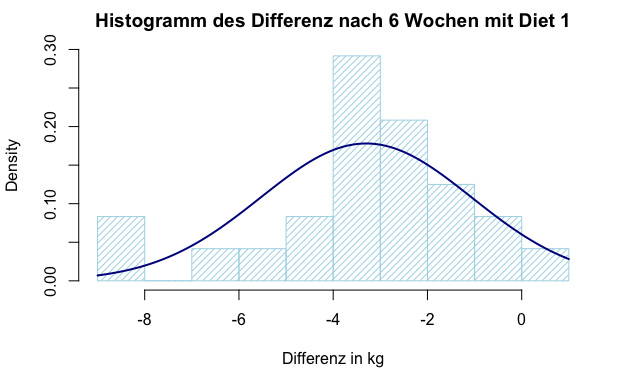

```r
g = df1$Differenz
m<-mean(g)
std<-sqrt(var(g))
hist(g, density=20, breaks=9, prob=TRUE,
     xlab="Differenz in kg",
     ylim=c(0, .3),
     col = "lightblue",
     main="Histogramm des Differenz nach 6 Wochen mit Diet 1")
curve(dnorm(x, mean=m, sd=std),
      col=colorchooose[1], lwd=2, add=TRUE, yaxt="n")
```

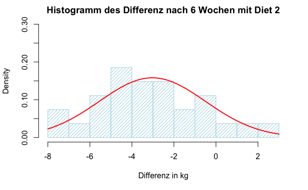

```r
g = df2$Differenz
m<-mean(g)
std<-sqrt(var(g))
hist(g, density=20, breaks=9, prob=TRUE,
     xlab="Differenz in kg",
     ylim=c(0, .3),
     col = "lightblue",
     main="Histogramm des Differenz nach 6 Wochen mit Diet 2")
curve(dnorm(x, mean=m, sd=std),
      col=colorchooose[2], lwd=2, add=TRUE, yaxt="n")
```

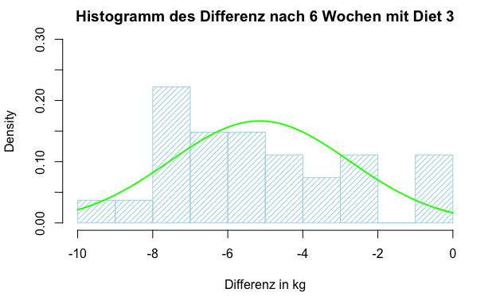

```r
g = df3$Differenz
m<-mean(g)
std<-sqrt(var(g))
hist(g, density=20, breaks=9, prob=TRUE,
     xlab="Differenz in kg",
     ylim=c(0, .3),
     col = "lightblue",
     main="Histogramm des Differenz nach 6 Wochen mit Diet 3")
curve(dnorm(x, mean=m, sd=std),
      col=colorchooose[3], lwd=2, add=TRUE, yaxt="n")
```

**Alternative**

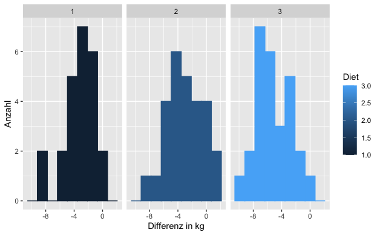

```r
foodDiet %>%
  group_by(Diet) %>%
  ggplot(aes(Differenz, color=Diet)) +
  geom_histogram(aes(fill = Diet), bins = 9) +
  facet_wrap(~Diet) +
  theme_grey()+
  labs(x= "Differenz in kg",y = "Anzahl" )
```

Die Normalverteilung ist nicht eindeutig durch das Histogram zu erkennen. Daher kann ein QQ-Plot zur bessern Einschätzung verwendet werden.

### QQ-Diagramm zur Prüfung des Normalverteilung

Die Werte werden der Größe nach geordnet. Als Vergleich dienen die Quantile der theoretischen Verteilung, die dem entsprechenden Verteilungswert zugehören. Wenn die Merkmalswerte aus der Vergleichsverteilung stammen, stimmen die empirischen und die theoretischen Quantile annähernd überein, d. h. die Werte liegen auf einer Diagonalen.

Große systematische Abweichungen von dieser Diagonalen geben einen Hinweis darauf, dass sich die theoretische und empirische Verteilung voneinander unterscheiden. DSie Werte müssen entlang einer aufsteigenden Gerade liegen, sodass eine ähnliche Verteilung vermutet werden kann.

```
[1] 19  8
```

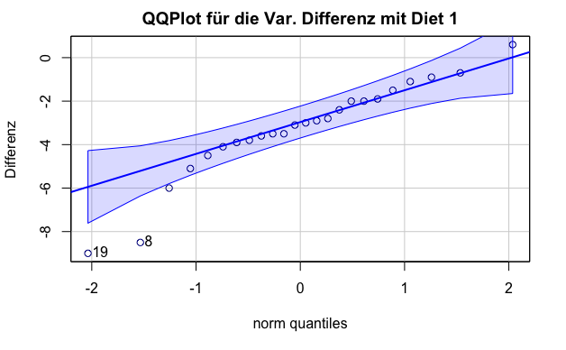

```r
qqPlot(df1$Differenz, main = "QQPlot für die Var. Differenz mit Diet 1", col = colorchooose[1], ylab = "Differenz")
```

```
[1]  3 25
```

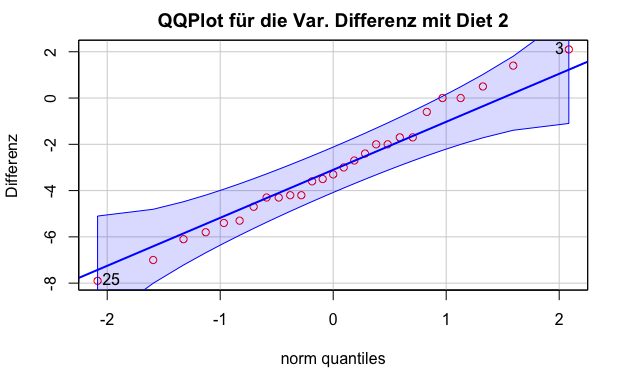

```r
qqPlot(df2$Differenz, main = "QQPlot für die Var. Differenz mit Diet 2", col = colorchooose[2], ylab = "Differenz")
```

```
[1] 19 11
```

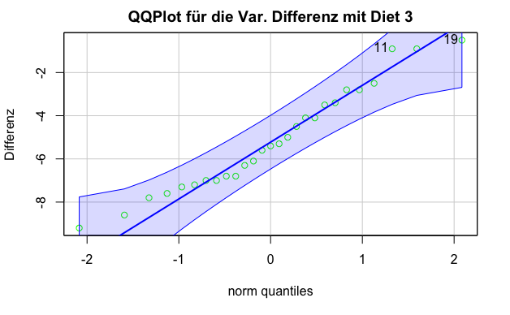

```r
qqPlot(df3$Differenz, main = "QQPlot für die Var. Differenz mit Diet 3", col = colorchooose[3], ylab = "Differenz")
```

Es liegt eine Normalverteilung der Differnz von preweight und weight 6weeks für alle drei Dieten.

## 3) Grundlegende Konzepte: Was ist t-Test für abhängige Stichproben?

Der t-Test für eine Stichprobe prüft anhand des Mittelwertes einer Stichprobe, ob der Mittelwert einer Grundgesamtheit gleich einem vorgegebenen Wert ist (bzw. kleiner oder größer). Die Fragestellung des t-Tests für eine Stichprobe wird oft so verkürzt: “Unterscheiden sich die Mittelwerte zwischen Grundgesamtheit und Stichprobe?”

Der t-Test für abhängige Stichproben testet, ob die Mittelwerte zweier abhängiger Stichproben verschieden sind. Von “abhängigen Stichproben” respektive “verbundenen Stichproben” wird gesprochen, wenn ein Messwert in einer Stichprobe und ein bestimmter Messwert in einer anderen Stichprobe sich gegenseitig beeinflussen. In diesem Beispiel sind die abhängigen Stichproben zwei Messwerte einer Person zu zwei verschiedenen Messzeitpunkten.

## 4) Deskriptive Statistiken und Korrelation

### Korrelation

#### Streudiagramm

Ein Streudiagramm, auch Punktwolke genannt (engl. scatter plot), ist die graphische Darstellung von beobachteten Wertepaaren zweier statistischer Merkmale. Diese Wertepaare werden in ein kartesisches Koordinatensystem eingetragen, wodurch sich eine Punktwolke ergibt.

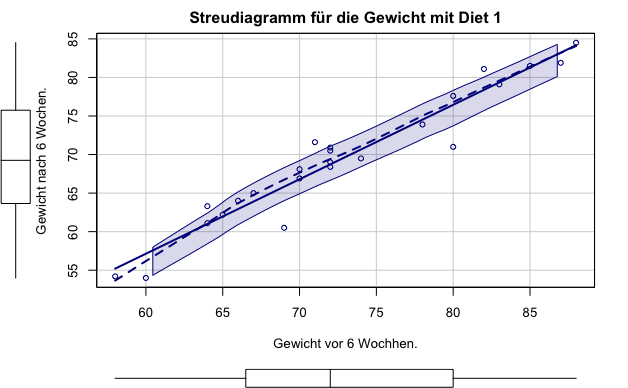

```r
scatterplot(df1$weight6weeks ~ df1$pre.weight,
            main = "Streudiagramm für die Gewicht mit Diet 1", ylab = "Gewicht nach 6 Wochen.", xlab= "Gewicht vor 6 Wochhen.", col= colorchooose[1] )
```

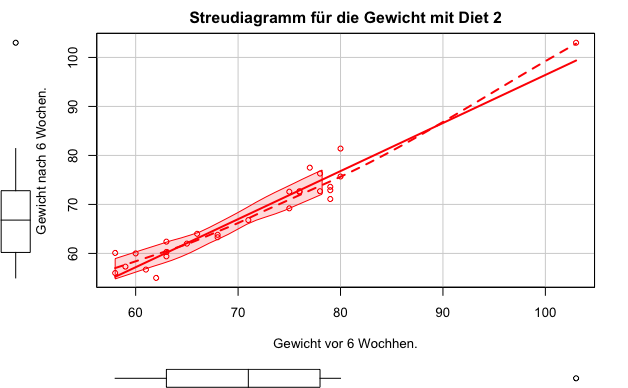

```r
scatterplot(df2$weight6weeks ~ df2$pre.weight,
            main = "Streudiagramm für die Gewicht mit Diet 2", ylab = "Gewicht nach 6 Wochen.", xlab= "Gewicht vor 6 Wochhen.", col= colorchooose[2] )
```

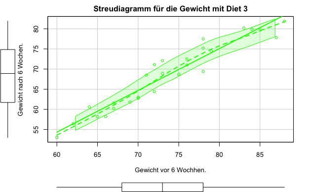

```r
scatterplot(df3$weight6weeks ~ df3$pre.weight,
            main = "Streudiagramm für die Gewicht mit Diet 3", ylab = "Gewicht nach 6 Wochen.", xlab= "Gewicht vor 6 Wochhen.", col= colorchooose[3] )
```

Es liegt eine positiver-linearer Zusammenhang zwichen dem Gewicht vor der Diät und dem Gewicht nach der Diät vor.

#### Korrelation nach Bravais-Pearson

Der Korrelationskoeffizient kann nur Werte im Bereich zwischen $-1$ und $+1$ annehmen. Ist er kleiner als Null ($r < 0$), so besteht ein negativer linearer Zusammenhang. Bei einem Wert grösser als Null ($r > 0$) besteht ein positiver linearer Zusammenhang und bei einem Wert von Null ($r = 0$) besteht kein Zusammenhang zwischen den Variablen.

```r
test1 <- cor.test(df1$weight6weeks,df1$pre.weight)
test1
```

```
    Pearson's product-moment correlation

data:  df1$weight6weeks and df1$pre.weight
t = 17.096, df = 22, p-value = 3.437e-14
alternative hypothesis: true correlation is not equal to 0
95 percent confidence interval:
 0.9181489 0.9846945
sample estimates:
      cor
0.9643656
```

```r
test2 <- cor.test(df2$weight6weeks,df2$pre.weight)
test2
```

```
    Pearson's product-moment correlation

data:  df2$weight6weeks and df2$pre.weight
t = 19.678, df = 25, p-value < 2.2e-16
alternative hypothesis: true correlation is not equal to 0
95 percent confidence interval:
 0.9327178 0.9860454
sample estimates:
      cor
0.9692021
```

```r
test3 <- cor.test(df3$weight6weeks,df3$pre.weight)
test3
```

```
    Pearson's product-moment correlation

data:  df3$weight6weeks and df3$pre.weight
t = 16.591, df = 25, p-value = 5.267e-15
alternative hypothesis: true correlation is not equal to 0
95 percent confidence interval:
 0.9077277 0.9806642
sample estimates:
      cor
0.9574649
```

Es wird ersichtlich, dass ein Zusammenhang zwischen dem Gewicht einer Person vor der Diät und dem Gewicht einer Person nach einer den Diäten gibt. ($r1 = 0.9643656, p1 = .000, n1 = 24; r2 = 0.9692021, p2 = .000, n2 = 27; r3 = 0.9574649, p3 = .000, n3 = 27$) vorliegt. Da $r$ einen positiven Wert aufweist, kann von einem positiven linearen und signifikanten Zusammenhang zwischen weight6weeks und pre.weight ausgegangen werden. Für das Beispiel ergibt sich eine starke Korrelation von $r$.Damit ist die Vorrausetzung der Abhängikeit der Variablen bestätigt.

### Deskriptive Statistiken

```r
describe(df1)
```

|  | vars | n | mean | sd | median | trimmed | mad | min | max | range | skew | kurtosis | se |
| --- | --- | --- | --- | --- | --- | --- | --- | --- | --- | --- | --- | --- | --- |
| Person | 1 | 24 | 12.50 | 7.07 | 12.50 | 12.50 | 8.90 | 1 | 24.0 | 23.0 | 0.00 | -1.35 | 1.44 |
| gender | 2 | 24 | 0.42 | 0.50 | 0.00 | 0.40 | 0.00 | 0 | 1.0 | 1.0 | 0.32 | -1.98 | 0.10 |
| Age | 3 | 24 | 40.88 | 9.73 | 40.50 | 40.95 | 11.12 | 22 | 60.0 | 38.0 | -0.11 | -0.80 | 1.99 |
| Height | 4 | 24 | 170.29 | 10.95 | 167.50 | 169.00 | 8.15 | 156 | 201.0 | 45.0 | 1.22 | 0.97 | 2.23 |
| pre.weight | 5 | 24 | 72.88 | 8.38 | 72.00 | 72.80 | 9.64 | 58 | 88.0 | 30.0 | 0.20 | -1.03 | 1.71 |
| Diet | 6 | 24 | 1.00 | 0.00 | 1.00 | 1.00 | 0.00 | 1 | 1.0 | 0.0 | NaN | NaN | 0.00 |
| weight6weeks | 7 | 24 | 69.58 | 8.40 | 69.25 | 69.76 | 8.30 | 54 | 84.5 | 30.5 | 0.01 | -0.86 | 1.71 |
| Differenz | 8 | 24 | -3.30 | 2.24 | -3.05 | -3.08 | 1.56 | -9 | 0.6 | 9.6 | -0.88 | 0.65 | 0.46 |

- pre.weight:($M=72.88, SD= 8.38, n= 24$),
- weight6weeks: ($M=69.58, SD = 8.40, n= 24$)

Daher liegt die Vermutung nahe, dass der Mittelwert von pre.weight größer ist als der Mittelwert von weight6weeks von Diet 1.

```r
describe(df2)
```

|  | vars | n | mean | sd | median | trimmed | mad | min | max | range | skew | kurtosis | se |
| --- | --- | --- | --- | --- | --- | --- | --- | --- | --- | --- | --- | --- | --- |
| Person | 1 | 27 | 38.00 | 7.94 | 38.0 | 38.00 | 10.38 | 25.0 | 51.0 | 26 | 0.00 | -1.33 | 1.53 |
| gender | 2 | 27 | 0.41 | 0.50 | 0.0 | 0.39 | 0.00 | 0.0 | 1.0 | 1 | 0.36 | -1.94 | 0.10 |
| Age | 3 | 27 | 39.00 | 9.51 | 39.0 | 39.52 | 8.90 | 16.0 | 54.0 | 38 | -0.41 | -0.26 | 1.83 |
| Height | 4 | 27 | 174.85 | 12.08 | 171.0 | 174.04 | 8.90 | 160.0 | 199.0 | 39 | 0.77 | -0.81 | 2.33 |
| pre.weight | 5 | 27 | 71.11 | 10.09 | 71.0 | 70.48 | 11.86 | 58.0 | 103.0 | 45 | 0.90 | 1.26 | 1.94 |
| Diet | 6 | 27 | 2.00 | 0.00 | 2.0 | 2.00 | 0.00 | 2.0 | 2.0 | 0 | NaN | NaN | 0.00 |
| weight6weeks | 7 | 27 | 68.09 | 10.22 | 66.8 | 67.08 | 9.64 | 55.0 | 103.0 | 48 | 1.31 | 2.57 | 1.97 |
| Differenz | 8 | 27 | -3.03 | 2.52 | -3.3 | -3.06 | 2.37 | -7.9 | 2.1 | 10 | 0.17 | -0.74 | 0.49 |

- pre.weight:($M=71.11, SD= 10.09, n= 27$),
- weight6weeks: ($M=68.09, SD = 10.22, n= 27$)

Daher liegt die Vermutung nahe, dass der Mittelwert von pre.weight größer ist als der Mittelwert von weight6weeks von Diet 2.

```r
describe(df3)
```

|  | vars | n | mean | sd | median | trimmed | mad | min | max | range | skew | kurtosis | se |
| --- | --- | --- | --- | --- | --- | --- | --- | --- | --- | --- | --- | --- | --- |
| Person | 1 | 27 | 65.00 | 7.94 | 65.0 | 65.00 | 10.38 | 52.0 | 78.0 | 26.0 | 0.00 | -1.33 | 1.53 |
| gender | 2 | 27 | 0.44 | 0.51 | 0.0 | 0.43 | 0.00 | 0.0 | 1.0 | 1.0 | 0.21 | -2.03 | 0.10 |
| Age | 3 | 27 | 37.78 | 10.32 | 36.0 | 37.61 | 10.38 | 20.0 | 58.0 | 38.0 | 0.15 | -0.86 | 1.99 |
| Height | 4 | 27 | 167.26 | 9.71 | 169.0 | 167.83 | 8.90 | 141.0 | 183.0 | 42.0 | -0.62 | 0.01 | 1.87 |
| pre.weight | 5 | 27 | 73.63 | 7.61 | 73.0 | 73.52 | 7.41 | 60.0 | 88.0 | 28.0 | 0.19 | -0.92 | 1.46 |
| Diet | 6 | 27 | 3.00 | 0.00 | 3.0 | 3.00 | 0.00 | 3.0 | 3.0 | 0.0 | NaN | NaN | 0.00 |
| weight6weeks | 7 | 27 | 68.48 | 8.24 | 68.9 | 68.59 | 10.53 | 53.0 | 81.9 | 28.9 | -0.04 | -1.25 | 1.59 |
| Differenz | 8 | 27 | -5.15 | 2.40 | -5.4 | -5.21 | 2.67 | -9.2 | -0.5 | 8.7 | 0.34 | -0.95 | 0.46 |

- pre.weight:($M=73.63, SD= 7.61, n= 27$),
- weight6weeks: ($M=68.48, SD = 8.24, n= 27$)

Daher liegt die Vermutung nahe, dass der Mittelwert von pre.weight größer ist als der Mittelwert von weight6weeks von Diet 3.

## 5) Ergebnisse des t-Tests für abhängige Stichproben

**alternative = “greater”** verwendet eine gerichtete Hypothese.

**paired = TRUE** ist dann abzuwenden, wenn die Stichprobe verbunden ist.

Das **“conf.level = .95”** beschreibt, dass ein Alphanivau von 0.05 verwendet wird.

```r
testVER1<- t.test(df1$pre.weight , df1$weight6weeks, alternative = "greater", paired = TRUE, conf.level = .95)
testVER1
```

```
    Paired t-test

data:  df1$pre.weight and df1$weight6weeks
t = 7.2168, df = 23, p-value = 1.198e-07
alternative hypothesis: true difference in means is greater than 0
95 percent confidence interval:
 2.516301      Inf
sample estimates:
mean of the differences
                    3.3
```

Die Teststatistik beträgt $t = 7.2168$ und der zugehoerige Signifikanzwert $p = 1.198e-07$. Damit gibt es einen signifikanten Gewichtverlust. ($t(23) = 7.2168, p = 1.198e-07, n= 24$).

```r
testVER2<- t.test(df2$pre.weight , df2$weight6weeks, alternative = "greater", paired = TRUE, conf.level = .95)
testVER2
```

```
    Paired t-test

data:  df2$pre.weight and df2$weight6weeks
t = 6.231, df = 26, p-value = 6.802e-07
alternative hypothesis: true difference in means is greater than 0
95 percent confidence interval:
 2.19764     Inf
sample estimates:
mean of the differences
               3.025926
```

Die Teststatistik beträgt $t = 6.231$ und der zugehoerige Signifikanzwert $p = 6.802e-07$. Damit gibt es einen signifikanten Gewichtverlust. ($t(26) = 6.231, p = 6.802e-07, n= 27$).

```r
testVER3<- t.test(df3$pre.weight , df3$weight6weeks, alternative = "greater", paired = TRUE, conf.level = .95)
testVER3
```

```
    Paired t-test

data:  df3$pre.weight and df3$weight6weeks
t = 11.167, df = 26, p-value = 1.015e-11
alternative hypothesis: true difference in means is greater than 0
95 percent confidence interval:
 4.361812      Inf
sample estimates:
mean of the differences
               5.148148
```

Die Teststatistik beträgt $t = 11.167$ und der zugehoerige Signifikanzwert $p = 1.015e-11$. Damit gibt es einen signifikanten Gewichtverlust. ($t(26) = 11.167, p = 1.015e-11, n= 27$).

## 6) Berechnung der Effektstärke

Die Effektstärke ist ein Maß für die Stärke eines Treatments bzw. Phänomens. Effektstärken sind damit eine der wichtigsten Größen in empirischen Studien. Zur Einschätzung der praktischen Bedeutsamkeit existieren verschiedene Effektstärkemaße, die bei der Interpretation der Größe eines Effektes helfen.

$$r=\sqrt{\frac{t^2}{t^2+df}}$$

```r
eff1 <- abs(sqrt(testVER1$statistic ^2/ (testVER1$statistic^2 + testVER1$parameter)))
sprintf("Effektstärke mit Diet 1: %.4f",eff1)
```

```
[1] "Effektstärke mit Diet 1: 0.8329"
```

```r
eff2 <- abs(sqrt(testVER2$statistic ^2/ (testVER2$statistic^2 + testVER2$parameter)))
sprintf("Effektstärke mit Diet 2: %.4f",eff2)
```

```
[1] "Effektstärke mit Diet 2: 0.7739"
```

```r
eff3 <- abs(sqrt(testVER3$statistic ^2/ (testVER3$statistic^2 + testVER3$parameter)))
sprintf("Effektstärke mit Diet 3: %.4f",eff3)
```

```
[1] "Effektstärke mit Diet 3: 0.9097"
```

Zur Beurteilung der Groesse des Effektes dient die Einteilung von Cohen (1992):
$$\begin{align}
\text{Schwacher Effekt: } 0.10 &< ||r|| < 0.30 \\
\text{Schwacher bis mittlerer Effekt: } 0.30 &= ||r|| \\
\text{Mittlerer Effekt: } 0.30 &< ||r|| < 0.50 \\
\text{Mittlerer bis starker Effekt: }0.50 &= ||r|| \\
\text{Starker Effekt: } 0.50 &< ||r||
\end{align}$$
Damit liegt ein sehr starken Effekt vor ($r1= 0.8329, r2= 0.7739, r3= 0.9097$).

## 7) Eine Aussage

Es zeigt sich, dass ein statistisch signifikaner Gewichtverlust nach allen Diäten vorliegt ($t1(23) = 7.2168, p1 = 1.198e-07; t2(26) = 6.231, p2 = 6.802e-07; t3(26) = 11.167, p3 = 1.015e-11$).

Der Mittelwert des Gewichts nach der Diät ist signifikant geringer als der Mittelwert des Gewichts vor Beginn der Diät.

Diät 1: + pre.weight:($M=72.88, SD= 8.38, n= 24$),  
+ weight6weeks: ($M=69.58, SD = 8.40, n= 24$)

Diät 2: + pre.weight:($M=71.11, SD= 10.09, n= 27$),  
+ weight6weeks: ($M=68.09, SD = 10.22, n= 27$)

Diät 3: + pre.weight:($M=73.63, SD= 7.61, n= 27$),  
+ weight6weeks: ($M=68.48, SD = 8.24, n= 27$)

**H0 wird auf jeden Fall abgelehnt**

Mit dem t-Test für abhängige Stichproben werden die Unterschiede der beiden Variablen/Messzeitpunkte untersucht. Um den Effekt der einzelnen Diäten zu überprüfen sind hier einzelne t-Tests durchgeführt worden, die in diesem Fall alle signifikant waren. Genauer könnten die Haupteffekte der Diäten mit einer ANOVA untersucht werden, hier werden auch nur mehrere t-tests durchgeführt.